# Age mixing (#age_mixing)

We will capture age mixing using a term to specify the absolute difference in the square root of ego and alter ages. Data on patterns of age mixing are from the WHPP sample and MMP[^1] samples, reweighted to Washington demographics. Since we only have data from the WHPP survey on the age of the most recent partner, we will restrict the MMP sample to the most recent partner as well, and weight the reported age mixing matrix in single years of age by the mean degree from the combined WHPP and ART-Net dataset. We will then take the averages of the off-diagonal terms to obtain a balanced matrix, which we will use to calculate the mean absolute difference between the square root of ego and alter ages. This approach is summarized below 1. obtain the row percentages for mixing in single years of age from the ego’s perspective (from WHPP and MMP data), 2. multiply these row percentages by the mean degree (or the mean rate of instantaneous partnerships) for egos of a given age (from WHPP and ART-Net data), 3. multiply this product by the target population size of each age. This will produce a weighted mixing matrix. 4. Balance the matrix by taking the mean of the off-diagonal elements. 5. Obtain the target statistic by taking the square root of ego and alter ages, calculating the absolute difference for each combination of ego and alter ages, weighting these differences by the edge count in the corresponding cell in the balanced matrix, and taking the mean of the non-zero elements.

This approach assumes that mixing with the unobserved ties follows the same pattern as mixing with the observed ties, and that men who did not report on their main/persistent/instantaneous partner have the same mixing propensities as those of the same age who did report on their main/persistnet/instantaneous partner. Since we did not observe age mixing to vary meaningfully by race/ethnicity or region (section @ref(explore_heterogeneity)), there is not an indication that we need to account for heterogeneity on these characteristics, such that this approach seems reasonable. Additionally, in section @ref(mrp_limitations), we did not observe any differences in main partnerships reported by those with 0 compared to those with 1+ persistent partnerships, suggesting that we can use data on the most recent partnership to represent all partnerships of that type.

## Main partnerships

The table below shows part of the unbalanced mixing matrix for main partnerships by age from the raked WHPP and MMP surveys, weighted by mean degree from the WHPP and ART-Net samples and scaled back to the size of the original samples. Note these counts are not integers because they are from the raked samples.

|  | 18 | 19 | 20 | 21 | 22 | 23 | 24 | 25 | 26 | 27 |
| --- | --- | --- | --- | --- | --- | --- | --- | --- | --- | --- |
| 18 | 0.00 | 2.48 | 1.80 | 0.00 | 0.00 | 0.00 | 0.00 | 1.03 | 0.00 | 0.00 |
| 19 | 0.00 | 10.13 | 0.95 | 1.29 | 0.00 | 0.00 | 0.00 | 0.00 | 0.00 | 0.62 |
| 20 | 0.00 | 1.29 | 2.09 | 0.00 | 0.00 | 2.01 | 0.00 | 0.00 | 0.00 | 1.04 |
| 21 | 0.00 | 1.31 | 2.06 | 0.75 | 2.04 | 0.00 | 1.06 | 0.00 | 1.06 | 1.06 |
| 22 | 0.61 | 0.00 | 0.86 | 0.37 | 1.93 | 1.43 | 0.33 | 0.00 | 0.00 | 0.86 |
| 23 | 0.00 | 0.00 | 0.00 | 0.54 | 0.82 | 4.64 | 0.82 | 0.82 | 3.04 | 0.35 |
| 24 | 0.00 | 1.22 | 0.00 | 0.00 | 0.99 | 1.41 | 0.99 | 0.99 | 1.22 | 0.65 |
| 25 | 0.00 | 0.00 | 1.06 | 0.00 | 0.00 | 2.12 | 2.12 | 1.98 | 2.45 | 1.32 |
| 26 | 0.00 | 0.00 | 1.77 | 0.00 | 0.00 | 2.50 | 1.25 | 1.01 | 0.44 | 1.10 |
| 27 | 0.00 | 0.00 | 0.00 | 0.00 | 0.00 | 0.78 | 0.73 | 1.10 | 1.58 | 2.21 |

Taking the average of the off-diagonal elements to balance the matrix, we get the following:

|  | 18 | 19 | 20 | 21 | 22 | 23 | 24 | 25 | 26 | 27 |
| --- | --- | --- | --- | --- | --- | --- | --- | --- | --- | --- |
| 18 | 0.00 | 1.24 | 0.90 | 0.00 | 0.30 | 0.00 | 0.00 | 0.51 | 0.00 | 0.00 |
| 19 | 1.24 | 10.13 | 1.12 | 1.30 | 0.00 | 0.00 | 0.61 | 0.00 | 0.00 | 0.31 |
| 20 | 0.90 | 1.12 | 2.09 | 1.03 | 0.43 | 1.00 | 0.00 | 0.53 | 0.88 | 0.52 |
| 21 | 0.00 | 1.30 | 1.03 | 0.75 | 1.20 | 0.27 | 0.53 | 0.00 | 0.53 | 0.53 |
| 22 | 0.30 | 0.00 | 0.43 | 1.20 | 1.93 | 1.12 | 0.66 | 0.00 | 0.00 | 0.43 |
| 23 | 0.00 | 0.00 | 1.00 | 0.27 | 1.12 | 4.64 | 1.12 | 1.47 | 2.77 | 0.57 |
| 24 | 0.00 | 0.61 | 0.00 | 0.53 | 0.66 | 1.12 | 0.99 | 1.55 | 1.23 | 0.69 |
| 25 | 0.51 | 0.00 | 0.53 | 0.00 | 0.00 | 1.47 | 1.55 | 1.98 | 1.73 | 1.21 |
| 26 | 0.00 | 0.00 | 0.88 | 0.53 | 0.00 | 2.77 | 1.23 | 1.73 | 0.44 | 1.34 |
| 27 | 0.00 | 0.31 | 0.52 | 0.53 | 0.43 | 0.57 | 0.69 | 1.21 | 1.34 | 2.21 |

The plot below shows the balanced age mixing matrix, with age collapsed into 5- to 10-year age bins.

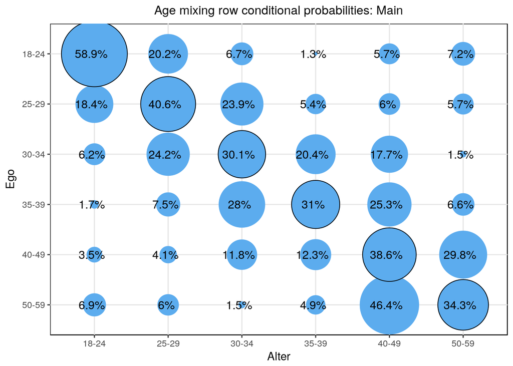

To calculate the target statistic, we take the absolute difference between the square root of each combination of ego and alter ages and weight it by the count in the corresponding cell in the balanced mixing matrix. We then take the mean of the non-zero weighted differences (because cells are zero if no partnerships of that age combination were reported, which should not be included), shown below.

```
## [1] 0.5383779
```

## Persistent partnerships

The table below shows part of the unbalanced mixing matrix for persistent partnerships by age from the raked WHPP and MMP surveys, weighted by mean degree from WHPP and ART-Net and scaled back to the size of the original samples. Note these counts are not integers because they are from the raked samples.

|  | 18 | 19 | 20 | 21 | 22 | 23 | 24 | 25 | 26 | 27 |
| --- | --- | --- | --- | --- | --- | --- | --- | --- | --- | --- |
| 18 | 3.60 | 0.00 | 0.00 | 0 | 1.26 | 0.00 | 0.00 | 0.00 | 0.00 | 0.00 |
| 19 | 0.00 | 0.00 | 0.00 | 0 | 0.00 | 0.00 | 0.00 | 0.00 | 0.00 | 0.00 |
| 20 | 0.00 | 0.00 | 0.00 | 0 | 2.75 | 0.00 | 0.00 | 1.64 | 0.00 | 0.00 |
| 21 | 0.00 | 0.00 | 0.00 | 0 | 0.00 | 1.26 | 0.00 | 2.29 | 0.00 | 2.29 |
| 22 | 0.00 | 0.00 | 2.41 | 0 | 1.70 | 0.00 | 0.00 | 0.00 | 0.00 | 0.00 |
| 23 | 0.00 | 0.00 | 0.00 | 0 | 2.48 | 0.00 | 1.08 | 0.00 | 2.48 | 0.00 |
| 24 | 0.00 | 0.00 | 0.00 | 0 | 0.00 | 1.33 | 0.00 | 0.00 | 0.00 | 5.14 |
| 25 | 1.43 | 2.64 | 0.00 | 0 | 0.00 | 0.00 | 0.00 | 2.02 | 0.00 | 0.88 |
| 26 | 0.00 | 0.00 | 0.00 | 0 | 0.00 | 0.00 | 0.00 | 0.00 | 0.00 | 0.00 |
| 27 | 0.00 | 0.00 | 0.00 | 0 | 0.00 | 0.00 | 0.00 | 0.00 | 0.00 | 0.00 |

Taking the average of the off-diagonal elements to balance the matrix, we get the following:

|  | 18 | 19 | 20 | 21 | 22 | 23 | 24 | 25 | 26 | 27 |
| --- | --- | --- | --- | --- | --- | --- | --- | --- | --- | --- |
| 18 | 3.60 | 0.00 | 0.00 | 0.00 | 0.63 | 0.00 | 0.00 | 0.71 | 0.00 | 0.00 |
| 19 | 0.00 | 0.00 | 0.00 | 0.00 | 0.00 | 0.00 | 0.00 | 1.32 | 0.00 | 0.00 |
| 20 | 0.00 | 0.00 | 0.00 | 0.00 | 2.58 | 0.00 | 0.00 | 0.82 | 0.00 | 0.00 |
| 21 | 0.00 | 0.00 | 0.00 | 0.00 | 0.00 | 0.63 | 0.00 | 1.14 | 0.00 | 1.14 |
| 22 | 0.63 | 0.00 | 2.58 | 0.00 | 1.70 | 1.24 | 0.00 | 0.00 | 0.00 | 0.00 |
| 23 | 0.00 | 0.00 | 0.00 | 0.63 | 1.24 | 0.00 | 1.20 | 0.00 | 1.24 | 0.00 |
| 24 | 0.00 | 0.00 | 0.00 | 0.00 | 0.00 | 1.20 | 0.00 | 0.00 | 0.00 | 2.57 |
| 25 | 0.71 | 1.32 | 0.82 | 1.14 | 0.00 | 0.00 | 0.00 | 2.02 | 0.00 | 0.44 |
| 26 | 0.00 | 0.00 | 0.00 | 0.00 | 0.00 | 1.24 | 0.00 | 0.00 | 0.00 | 0.00 |
| 27 | 0.00 | 0.00 | 0.00 | 1.14 | 0.00 | 0.00 | 2.57 | 0.44 | 0.00 | 0.00 |

The plot below shows the balanced age mixing matrix, with age collapsed into 5- to 10-year age bins.

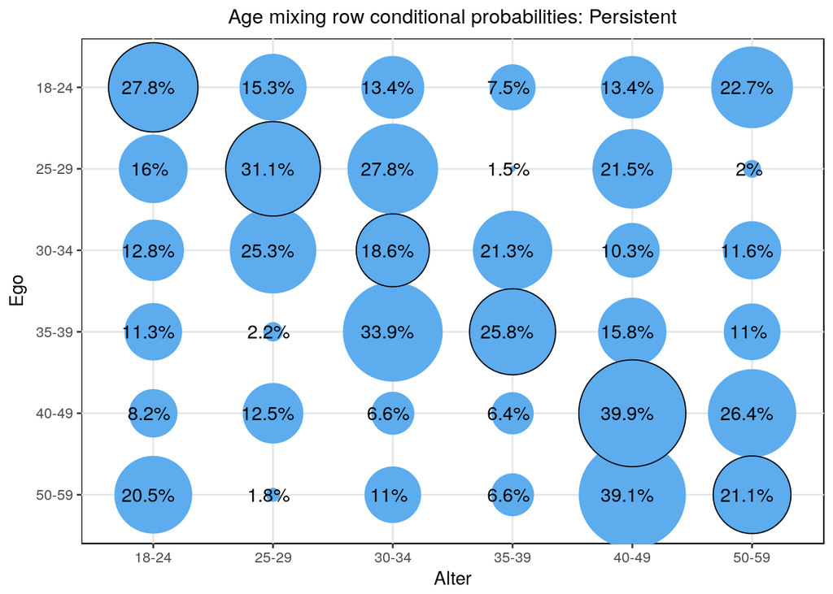

To calculate the target statistic, we take the absolute difference between the square root of each combination of ego and alter ages and weight it by the count in the corresponding cell in the balanced mixing matrix. We then take the mean of the non-zero weighted differences (because cells are zero if no partnerships of that age combination were reported, which should not be included), shown below.

```
## [1] 0.8252217
```

## Instantaneous partnerships

The table below shows part of the the unbalanced mixing matrix for instantaneous partnerships by age from the raked WHPP and MMP surveys, weighted by the mean rate of one-time partnerships from WHPP and ART-Net and scaled back to the size of the original WHPP sample. Note these counts are not integers because they are from the re-weighted samples.

|  | 18 | 19 | 20 | 21 | 22 | 23 | 24 | 25 | 26 | 27 |
| --- | --- | --- | --- | --- | --- | --- | --- | --- | --- | --- |
| 18 | 0.04 | 0.00 | 0.01 | 0 | 0.01 | 0.02 | 0.00 | 0.00 | 0.00 | 0.01 |
| 19 | 0.00 | 0.06 | 0.02 | 0 | 0.00 | 0.00 | 0.00 | 0.00 | 0.00 | 0.00 |
| 20 | 0.00 | 0.00 | 0.02 | 0 | 0.00 | 0.00 | 0.00 | 0.03 | 0.00 | 0.00 |
| 21 | 0.00 | 0.00 | 0.00 | 0 | 0.00 | 0.00 | 0.00 | 0.00 | 0.00 | 0.03 |
| 22 | 0.00 | 0.00 | 0.00 | 0 | 0.05 | 0.00 | 0.00 | 0.03 | 0.04 | 0.00 |
| 23 | 0.00 | 0.00 | 0.00 | 0 | 0.00 | 0.00 | 0.03 | 0.00 | 0.00 | 0.00 |
| 24 | 0.00 | 0.00 | 0.00 | 0 | 0.04 | 0.07 | 0.03 | 0.02 | 0.00 | 0.00 |
| 25 | 0.00 | 0.00 | 0.00 | 0 | 0.00 | 0.00 | 0.00 | 0.00 | 0.03 | 0.00 |
| 26 | 0.00 | 0.00 | 0.00 | 0 | 0.00 | 0.08 | 0.14 | 0.10 | 0.04 | 0.00 |
| 27 | 0.00 | 0.00 | 0.00 | 0 | 0.00 | 0.00 | 0.00 | 0.00 | 0.17 | 0.00 |

Taking the average of the off-diagonal elements to balance the matrix, we get the following:

|  | 18 | 19 | 20 | 21 | 22 | 23 | 24 | 25 | 26 | 27 |
| --- | --- | --- | --- | --- | --- | --- | --- | --- | --- | --- |
| 18 | 0.04 | 0.00 | 0.00 | 0.00 | 0.00 | 0.01 | 0.00 | 0.00 | 0.00 | 0.01 |
| 19 | 0.00 | 0.06 | 0.01 | 0.00 | 0.00 | 0.00 | 0.00 | 0.00 | 0.00 | 0.00 |
| 20 | 0.00 | 0.01 | 0.02 | 0.00 | 0.00 | 0.00 | 0.00 | 0.02 | 0.00 | 0.00 |
| 21 | 0.00 | 0.00 | 0.00 | 0.00 | 0.00 | 0.00 | 0.00 | 0.00 | 0.00 | 0.01 |
| 22 | 0.00 | 0.00 | 0.00 | 0.00 | 0.05 | 0.00 | 0.02 | 0.02 | 0.02 | 0.00 |
| 23 | 0.01 | 0.00 | 0.00 | 0.00 | 0.00 | 0.00 | 0.05 | 0.00 | 0.04 | 0.00 |
| 24 | 0.00 | 0.00 | 0.00 | 0.00 | 0.02 | 0.05 | 0.03 | 0.01 | 0.07 | 0.00 |
| 25 | 0.00 | 0.00 | 0.02 | 0.00 | 0.02 | 0.00 | 0.01 | 0.00 | 0.07 | 0.00 |
| 26 | 0.00 | 0.00 | 0.00 | 0.00 | 0.02 | 0.04 | 0.07 | 0.07 | 0.04 | 0.08 |
| 27 | 0.01 | 0.00 | 0.00 | 0.01 | 0.00 | 0.00 | 0.00 | 0.00 | 0.08 | 0.00 |

The plot below shows the balanced age mixing matrix, with age collapsed into 5- to 10-year age bins.

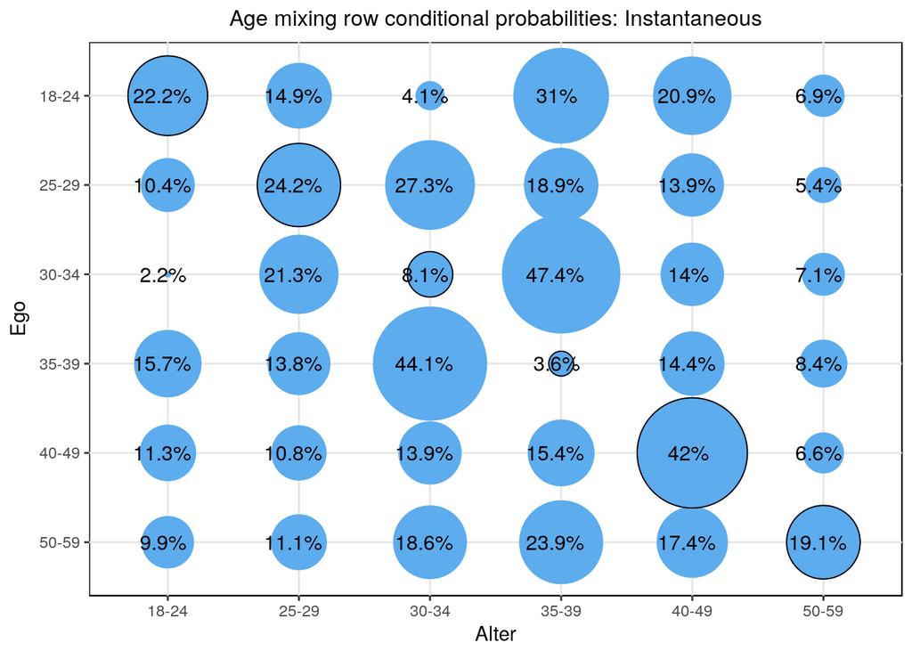

To calculate the target statistic, we take the absolute difference between the square root of each combination of ego and alter ages and weight it by the count in the corresponding cell in the balanced mixing matrix. We then take the mean of the non-zero weighted differences (because cells are zero if no partnerships of that age combination were reported, which should not be included), shown below.

```
## [1] 0.7940946
```

[^1]: MMP measured alter age in 5-year increments. Using the lower bound of the range for alter age yielded estimates of the absolute difference in the square root of ego and alter ages of 0.5442927, 0.8398329, and 0.813158 for main, persistent, and instantaneous partnerships, respectively. Using the midpoint of the range yielded estimates of 0.5383779, 0.8252217, and 0.7940946, and using the upper bound yielded estimates of 0.5351637, 0.8124105, 0.8180763. We use the mid-point of the range for target statistics. For comparison, using data from ART-Net and WHPP for age mixing, estimates were 0.5518785, 0.8413099, and 0.7753907.